# CS 556 Final Group Project: Near-Earth Objects

## Performance optimization using other models

After the implementation of parametric models such as SVM, we have decided to try non-parametric models too, such as **Decision Tree and Random Forest**, which make no assumptions about the distribution of data and are not influenced by outliers and multicollinearity to some fair extent.

### 1: Decision Tree

```
Classification report:
               precision    recall  f1-score   support

           0       0.94      0.94      0.94     16400
           1       0.43      0.45      0.44      1768

    accuracy                           0.89     18168
   macro avg       0.69      0.69      0.69     18168
weighted avg       0.89      0.89      0.89     18168
```

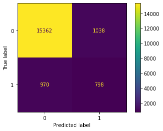

```python
from sklearn.tree import DecisionTreeClassifier

x=data.drop(columns='hazardous')
y=data.hazardous


x_train,x_test,y_train,y_test=train_test_split(x,y,test_size=0.20,stratify=y, random_state = 42)

DT = DecisionTreeClassifier()

DT_model = DT.fit(x_train,y_train)
y_pred = DT_model.predict(x_test)

evaluation(y_test,y_pred)
```

### 2: Random Forest

```
Classification report:
               precision    recall  f1-score   support

           0       0.94      0.97      0.95     16400
           1       0.61      0.38      0.47      1768

    accuracy                           0.92     18168
   macro avg       0.77      0.68      0.71     18168
weighted avg       0.90      0.92      0.91     18168
```

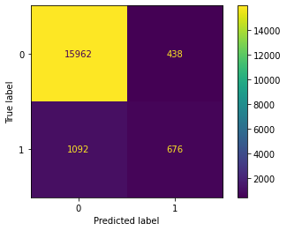

```python
from sklearn.ensemble import RandomForestClassifier

RF = RandomForestClassifier()

RF_model = RF.fit(x_train,y_train)
y_pred = RF_model.predict(x_test)

evaluation(y_test,y_pred)
```

## Conclusion

### Visualization of PCA Model

For this plot we'll use the PCA that used one-class SVC, since it appeared to perform the best (out of the other classifiers trained on principal components) on recognizing samples from both classes in the test set.

For our visualization, we will be using the `DecisionBoundaryDisplay` class.

```python
from sklearn.inspection import DecisionBoundaryDisplay
from sklearn.pipeline import make_pipeline
from matplotlib.colors import ListedColormap
```

Setup code:

```python
gamma = 1
_, X_test, _, y_test = gamma_kernel_reduced[gamma]
svm = models_reduced[gamma]

pipe = make_pipeline(feature_map_nystroem_reduced, svm)

red_green_colormap = ListedColormap(["green", "red"])
```

Plotting function:

```python
def plot_svm_2D(title, clf, X_test, y_test, gamma):
    '''Shows the plot of our SVM in color.'''
    # Set-up 2x2 grid for plotting.
    fig, ax = plt.subplots(figsize=(6, 6))
    # plot the samples and decision boundary
    X0, X1 = X_test[:, 0], X_test[:, 1]

    disp = DecisionBoundaryDisplay.from_estimator(
        clf,
        X_test,
        response_method="predict",
        cmap=red_green_colormap,
        alpha=0.8,
        ax=ax,
        xlabel="PC 1",
        ylabel="PC 2",
        plot_method="contour",
        grid_resolution=100
    )
    scatter = ax.scatter(X0, X1,
               c=y_test,
               cmap=red_green_colormap,
               edgecolor="black",
               s=20, edgecolors='k')
    #add legend
    lines, _ = scatter.legend_elements()
    labels = ["Non-hazardous", "Hazardous"]
    new_legend_elems = (lines, labels)
    plt.legend(*new_legend_elems)

    # final presentation pieces
    ax.set_xticks(())
    ax.set_yticks(())
    ax.set_title(title)

    plt.show()
```

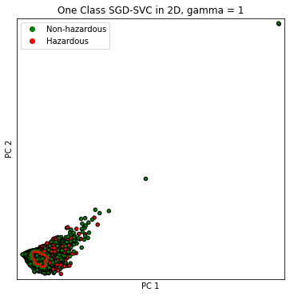

```python
plot_svm_2D(f"One Class SGD-SVC in 2D, gamma = {gamma}",
            pipe, X_test_reduced, y_test, gamma)
```

This visualization corroborates our quantitative results:

- there are far more non-hazardous points than hazardous ones
- we can also see that the decision boundary (colored in red) encircles an area of what appears to be alot of green points - this is in line with our confusion matrix, which indeed showed **a high number of false positives**
- also - the fact that the decision boundary is roughly a circle is indicative of how we used the RBF kernel, rather than just a linear one

Note: please forgive us for highlighting the decision boundary in red - I know the instructions said to use black but the red color stands out better.

### Before and After PCA - *which model is most effective, and why?*

Ultimately, in comparing the One Class SVM model trained on 4 features vs. the one trained on 2 principal components (PCs), we observe that, with `gamma = 1`, both models achieve an accuracy of 85%. However, the model trained on 4 features scores higher on `precision, recall, and f1-score` with a value of `0.59`; on the other hand, the models trained on PCs achieves a slightly lower score of `0.57`. All of the afforementioned metrics are with respect to the test set. This difference in perfomance suggests the model trained on 4 features is more effective.

1. **Non-linearity**: PCA is best suited to datasets where the two classes are linearly separable. This was not the case for the NEOs dataset. Therefore, even though we reduced dimensionality, that itself didn't remove the problem of trying to fit a support vector machine to the dataset.
2. **Non-orthogonal structure**: PCA works by finding an axis along which to project the samples of our dataset onto, such that we preserve maximal information about the spread of our values. This projection needs to happen orthogonally, so that the PCs will be linearly separable; however for our dataset, we can see that our PCs kind of form one large "clump" in 2D. This indicates that PCA didn't help much for this dataset, since we don't improve the linear separability of our data. And as discussed above, this is bad news for training SVMs.

**Other conclusions** from this project is regarding our use of the RBF kernel. Rather than finding a clear winner between the RBF and linear kernels, we observe a tradeoff: while our SVM trained on a linear kernel had a slightly higher test F1-score, the RBF kernel increased our models recall value on the "hazardous" class, in exchange for slight F1-score decrease (< 2%).

### Next Steps:

Our group would be excited to pursue further work in this problem domain. Here are a few ideas we have already considered: